# CURSO DE ACTUALIZACION EN ESTADISTICA

#### Profesor: Dr. José Manuel MAGALLANES, Ph.D

## Sesión 2:

## **Exploración de Datos Categóricos en R**

## Ejercicios:

Este archivo contiene información de proyectos de exploración minera para el 2018:

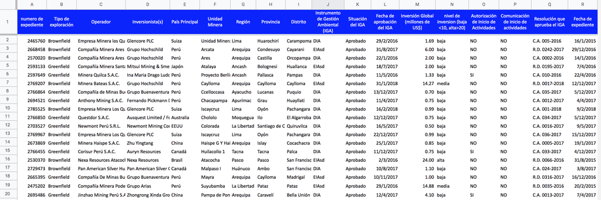

1. Sabiendo que el link a esa data es:

https://docs.google.com/spreadsheets/d/e/2PACX-1vSaZQ88MJaKumH0inYTW5mWZhQmcfUhbxT8is0MbX26Ypj8JBnYv58muKhqzDt37UF2tpJxLywNe7Ct/pub?gid=130298120&single=FALSE&output=csv

Traiga tal archivo a RStudio usando el comando **read.csv**, dele nombre *data2018* al objeto que recibe la data:

2. Vea los nombres usando el comando **names**. Luego, cambielos siguiendo esta recomendacion:

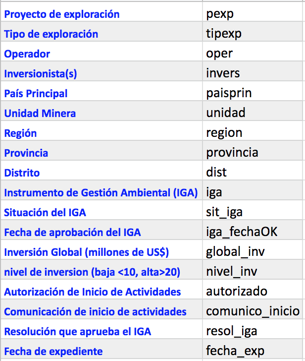

3. Use el comando **str** para ver los tipos de datos:

Identifique las columnas con *identificadores*.

4. Pida un resumen estadístico usando **summary**:
5. Convierta en categoría a las siguientes variables usando el comando **lapply**:
- tipexp
- paisprin
- iga
- sit_iga

Luego, pida el resumen estadístico nuevamente.

5. Use el comando **table** con la variable *nivel_inv*:
6. Decida a qué tipo de categoríca debe ser convertida la variable *nivel_inv*, y hágalo:

Vuelva a pedir el resumen estadístico:

7. Haga un gráfico para la variable país principal (*paisprin*).
8. Haga un gráfico para la variable nivel de inversión (*nivel_inv*).
9. Calcule e interprete el indice de Herfindahl- Hirschman, así como el de Laakso - Taagepera para la variable *paisprin*.
10. Haga una tabla de frecuencia para *paisprin* y para *nivel_inv*. Incluya los elementos permitidos.

[Volver al programa del curso](https://coursesandtutorials.github.io/Estadistica/)